# Loading and preprocessing the data

Please note that my opinion of appropriate tab width differs from the instructor's. I use a tab width of 2. I can see that a width of 2 versus 4 is debatable. I would not consider a tab width of 8. My opinion is that this width becomes a distraction.

### Loading and preprocessing the data

```r
setwd(file.path(Sys.getenv("HOME"),
  "Dropbox/Private/data science/Reproducible Research/project1"))
library(lubridate)
library(dplyr)
# Load the data
actmon <- read.csv("activity.csv")
# Convert the date column to actual dates
actmon$date <- ymd(actmon$date)
```

### What is mean total number of steps taken per day?

Note that all records with `NA` values were excluded for everything in this section. At least one day had nothing but `NA` values and such days are therefore not shown.

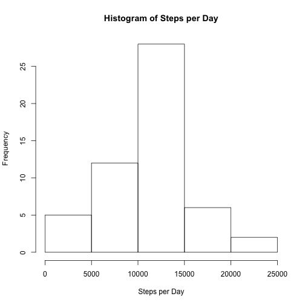

```r
library(xtable)
actmon_complete <- actmon[complete.cases(actmon),]
actmon_complete <- group_by(actmon_complete, date)
actmon_total_steps <- summarize(actmon_complete, total=sum(steps))
hist(actmon_total_steps$total, main="Histogram of Steps per Day",
  xlab="Steps per Day")
```

#### Mean Steps per Day Table

```r
actmon_mean_steps <- summarize(actmon_complete, mean_steps=mean(steps))
actmon_mean_steps$date = as.character(actmon_mean_steps$date)
print(xtable(as.data.frame(actmon_mean_steps)),type="html")
```

|  | date | mean_steps |
| --- | --- | --- |
| 1 | 2012-10-02 | 0.44 |
| 2 | 2012-10-03 | 39.42 |
| 3 | 2012-10-04 | 42.07 |
| 4 | 2012-10-05 | 46.16 |
| 5 | 2012-10-06 | 53.54 |
| 6 | 2012-10-07 | 38.25 |
| 7 | 2012-10-09 | 44.48 |
| 8 | 2012-10-10 | 34.38 |
| 9 | 2012-10-11 | 35.78 |
| 10 | 2012-10-12 | 60.35 |
| 11 | 2012-10-13 | 43.15 |
| 12 | 2012-10-14 | 52.42 |
| 13 | 2012-10-15 | 35.20 |
| 14 | 2012-10-16 | 52.38 |
| 15 | 2012-10-17 | 46.71 |
| 16 | 2012-10-18 | 34.92 |
| 17 | 2012-10-19 | 41.07 |
| 18 | 2012-10-20 | 36.09 |
| 19 | 2012-10-21 | 30.63 |
| 20 | 2012-10-22 | 46.74 |
| 21 | 2012-10-23 | 30.97 |
| 22 | 2012-10-24 | 29.01 |
| 23 | 2012-10-25 | 8.65 |
| 24 | 2012-10-26 | 23.53 |
| 25 | 2012-10-27 | 35.14 |
| 26 | 2012-10-28 | 39.78 |
| 27 | 2012-10-29 | 17.42 |
| 28 | 2012-10-30 | 34.09 |
| 29 | 2012-10-31 | 53.52 |
| 30 | 2012-11-02 | 36.81 |
| 31 | 2012-11-03 | 36.70 |
| 32 | 2012-11-05 | 36.25 |
| 33 | 2012-11-06 | 28.94 |
| 34 | 2012-11-07 | 44.73 |
| 35 | 2012-11-08 | 11.18 |
| 36 | 2012-11-11 | 43.78 |
| 37 | 2012-11-12 | 37.38 |
| 38 | 2012-11-13 | 25.47 |
| 39 | 2012-11-15 | 0.14 |
| 40 | 2012-11-16 | 18.89 |
| 41 | 2012-11-17 | 49.79 |
| 42 | 2012-11-18 | 52.47 |
| 43 | 2012-11-19 | 30.70 |
| 44 | 2012-11-20 | 15.53 |
| 45 | 2012-11-21 | 44.40 |
| 46 | 2012-11-22 | 70.93 |
| 47 | 2012-11-23 | 73.59 |
| 48 | 2012-11-24 | 50.27 |
| 49 | 2012-11-25 | 41.09 |
| 50 | 2012-11-26 | 38.76 |
| 51 | 2012-11-27 | 47.38 |
| 52 | 2012-11-28 | 35.36 |
| 53 | 2012-11-29 | 24.47 |

#### Median Steps per Day Table

```r
actmon_median_steps <- summarize(actmon_complete, median_steps=median(steps))
actmon_median_steps$date = as.character(actmon_median_steps$date)
print(xtable(as.data.frame(actmon_median_steps)),type="html")
```

|  | date | median_steps |
| --- | --- | --- |
| 1 | 2012-10-02 | 0.00 |
| 2 | 2012-10-03 | 0.00 |
| 3 | 2012-10-04 | 0.00 |
| 4 | 2012-10-05 | 0.00 |
| 5 | 2012-10-06 | 0.00 |
| 6 | 2012-10-07 | 0.00 |
| 7 | 2012-10-09 | 0.00 |
| 8 | 2012-10-10 | 0.00 |
| 9 | 2012-10-11 | 0.00 |
| 10 | 2012-10-12 | 0.00 |
| 11 | 2012-10-13 | 0.00 |
| 12 | 2012-10-14 | 0.00 |
| 13 | 2012-10-15 | 0.00 |
| 14 | 2012-10-16 | 0.00 |
| 15 | 2012-10-17 | 0.00 |
| 16 | 2012-10-18 | 0.00 |
| 17 | 2012-10-19 | 0.00 |
| 18 | 2012-10-20 | 0.00 |
| 19 | 2012-10-21 | 0.00 |
| 20 | 2012-10-22 | 0.00 |
| 21 | 2012-10-23 | 0.00 |
| 22 | 2012-10-24 | 0.00 |
| 23 | 2012-10-25 | 0.00 |
| 24 | 2012-10-26 | 0.00 |
| 25 | 2012-10-27 | 0.00 |
| 26 | 2012-10-28 | 0.00 |
| 27 | 2012-10-29 | 0.00 |
| 28 | 2012-10-30 | 0.00 |
| 29 | 2012-10-31 | 0.00 |
| 30 | 2012-11-02 | 0.00 |
| 31 | 2012-11-03 | 0.00 |
| 32 | 2012-11-05 | 0.00 |
| 33 | 2012-11-06 | 0.00 |
| 34 | 2012-11-07 | 0.00 |
| 35 | 2012-11-08 | 0.00 |
| 36 | 2012-11-11 | 0.00 |
| 37 | 2012-11-12 | 0.00 |
| 38 | 2012-11-13 | 0.00 |
| 39 | 2012-11-15 | 0.00 |
| 40 | 2012-11-16 | 0.00 |
| 41 | 2012-11-17 | 0.00 |
| 42 | 2012-11-18 | 0.00 |
| 43 | 2012-11-19 | 0.00 |
| 44 | 2012-11-20 | 0.00 |
| 45 | 2012-11-21 | 0.00 |
| 46 | 2012-11-22 | 0.00 |
| 47 | 2012-11-23 | 0.00 |
| 48 | 2012-11-24 | 0.00 |
| 49 | 2012-11-25 | 0.00 |
| 50 | 2012-11-26 | 0.00 |
| 51 | 2012-11-27 | 0.00 |
| 52 | 2012-11-28 | 0.00 |
| 53 | 2012-11-29 | 0.00 |

### What Is the Average Daily Activity Pattern?

#### 1. Make a time series plot of the 5-minute interval (x-axis) and the average number of steps taken, averaged across all days

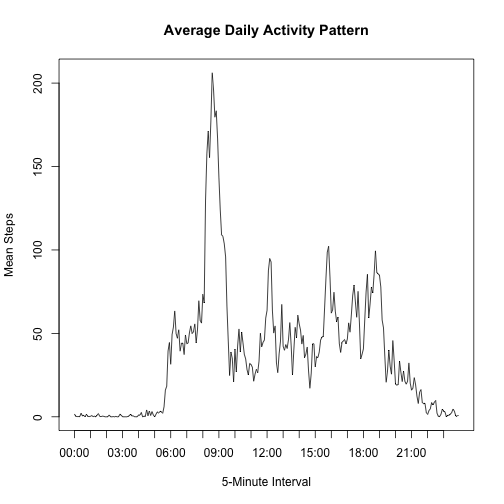

```r
actmon_complete <- actmon[complete.cases(actmon),]
actmon_interval <- group_by(actmon_complete, interval)
actmon_interval <- summarize(actmon_interval, mean_steps=mean(steps))
actmon_interval$rowid <- as.integer(row.names(actmon_interval))
actmon_interval$labels <- sub("(\\d\\d)(\\d\\d)", "\\1:\\2",
  formatC(actmon_interval$interval, width=4, format="d", flag="0"))
plot(actmon_interval$rowid, actmon_interval$mean_steps, type="l",
  xlab="5-Minute Interval", ylab="Mean Steps",
  main="Average Daily Activity Pattern", xaxt="n")
tics <- seq(1, 288, by=12)
axis(side=1,at=actmon_interval[tics,]$rowid,
  labels=actmon_interval[tics,]$labels)
```

#### Which 5-minute interval, on average across all days in the dataset, contains the maximum number of steps?

```r
actmon_interval[actmon_interval$mean_steps == max(actmon_interval$mean_steps),]
```

```
## Source: local data frame [1 x 4]
##
##   interval mean_steps rowid labels
## 1      835      206.2   104  08:35
```

### Imputing Missing Values

#### 1. Total number of rows with `NA`

```r
rows_with_na <- nrow(actmon) - nrow(actmon_complete)
```

The total number of rows with at least one `NA` value is 2304.

#### 2. Devise a strategy for filling in all of the missing values

My first step is to show that the `date` and `interval` fields do not contain any `NA`s.

```r
any(is.na(actmon$interval)) # returns FALSE
```

```
## [1] FALSE
```

```r
any(is.na(actmon$date)) # returns false
```

```
## [1] FALSE
```

So I am concerned only with the one remaining column, `steps`.

#### 3. Create a new dataset that is equal to the original dataset but with the missing values filled in.

This is `actmon_imputed`.

```r
actmon_means <- actmon %>%
  group_by(interval) %>%
  summarize(interval_mean=mean(steps, na.rm=TRUE))
actmon_imputed <- actmon
actmon_imputed$interval_mean <- actmon_means$interval_mean
actmon_imputed$steps <- ifelse(is.na(actmon_imputed$steps), actmon_imputed$interval_mean, actmon_imputed$steps)
actmon_imputed$interval_mean <- NULL
str(actmon_imputed)
```

```
## 'data.frame':    17568 obs. of  3 variables:
##  $ steps   : num  1.717 0.3396 0.1321 0.1509 0.0755 ...
##  $ date    : POSIXct, format: "2012-10-01" "2012-10-01" ...
##  $ interval: int  0 5 10 15 20 25 30 35 40 45 ...
```

```r
summary(actmon_imputed)
```

```
##      steps            date               interval
##  Min.   :  0.0   Min.   :2012-10-01   Min.   :   0
##  1st Qu.:  0.0   1st Qu.:2012-10-16   1st Qu.: 589
##  Median :  0.0   Median :2012-10-31   Median :1178
##  Mean   : 37.4   Mean   :2012-10-31   Mean   :1178
##  3rd Qu.: 27.0   3rd Qu.:2012-11-15   3rd Qu.:1766
##  Max.   :806.0   Max.   :2012-11-30   Max.   :2355
```

The number of cases in `actmon_imputed` is 17568. The number of complete cases in `actmon_imputed` is 17568. These two numbers must be equal.

#### 4. Make a histogram of the total number of steps taken each data and calculate and report the mean and median total number of steps taken each day.

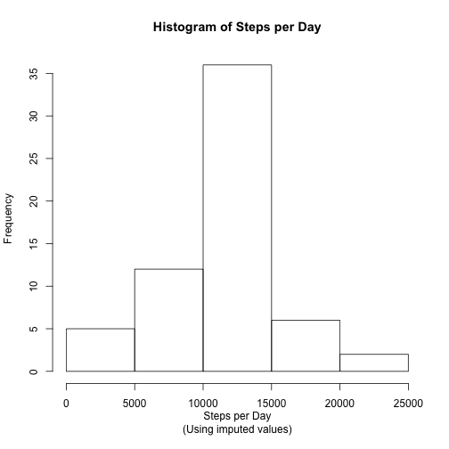

```r
actmon_imputed_total <- group_by(actmon_imputed, date) %>%
  summarize(total=sum(steps))
hist(actmon_imputed_total$total, main="Histogram of Steps per Day", xlab="Steps per Day\n(Using imputed values)")
```

#### Mean Steps per Day Table (using imputed values)

```r
actmon_mean_steps <- group_by(actmon_imputed, date) %>%
  summarize(mean_steps=mean(steps))
actmon_mean_steps$date <- as.character(actmon_mean_steps$date)
print(xtable(as.data.frame(actmon_mean_steps)),type="html")
```

|  | date | mean_steps |
| --- | --- | --- |
| 1 | 2012-10-01 | 37.38 |
| 2 | 2012-10-02 | 0.44 |
| 3 | 2012-10-03 | 39.42 |
| 4 | 2012-10-04 | 42.07 |
| 5 | 2012-10-05 | 46.16 |
| 6 | 2012-10-06 | 53.54 |
| 7 | 2012-10-07 | 38.25 |
| 8 | 2012-10-08 | 37.38 |
| 9 | 2012-10-09 | 44.48 |
| 10 | 2012-10-10 | 34.38 |
| 11 | 2012-10-11 | 35.78 |
| 12 | 2012-10-12 | 60.35 |
| 13 | 2012-10-13 | 43.15 |
| 14 | 2012-10-14 | 52.42 |
| 15 | 2012-10-15 | 35.20 |
| 16 | 2012-10-16 | 52.38 |
| 17 | 2012-10-17 | 46.71 |
| 18 | 2012-10-18 | 34.92 |
| 19 | 2012-10-19 | 41.07 |
| 20 | 2012-10-20 | 36.09 |
| 21 | 2012-10-21 | 30.63 |
| 22 | 2012-10-22 | 46.74 |
| 23 | 2012-10-23 | 30.97 |
| 24 | 2012-10-24 | 29.01 |
| 25 | 2012-10-25 | 8.65 |
| 26 | 2012-10-26 | 23.53 |
| 27 | 2012-10-27 | 35.14 |
| 28 | 2012-10-28 | 39.78 |
| 29 | 2012-10-29 | 17.42 |
| 30 | 2012-10-30 | 34.09 |
| 31 | 2012-10-31 | 53.52 |
| 32 | 2012-11-01 | 37.38 |
| 33 | 2012-11-02 | 36.81 |
| 34 | 2012-11-03 | 36.70 |
| 35 | 2012-11-04 | 37.38 |
| 36 | 2012-11-05 | 36.25 |
| 37 | 2012-11-06 | 28.94 |
| 38 | 2012-11-07 | 44.73 |
| 39 | 2012-11-08 | 11.18 |
| 40 | 2012-11-09 | 37.38 |
| 41 | 2012-11-10 | 37.38 |
| 42 | 2012-11-11 | 43.78 |
| 43 | 2012-11-12 | 37.38 |
| 44 | 2012-11-13 | 25.47 |
| 45 | 2012-11-14 | 37.38 |
| 46 | 2012-11-15 | 0.14 |
| 47 | 2012-11-16 | 18.89 |
| 48 | 2012-11-17 | 49.79 |
| 49 | 2012-11-18 | 52.47 |
| 50 | 2012-11-19 | 30.70 |
| 51 | 2012-11-20 | 15.53 |
| 52 | 2012-11-21 | 44.40 |
| 53 | 2012-11-22 | 70.93 |
| 54 | 2012-11-23 | 73.59 |
| 55 | 2012-11-24 | 50.27 |
| 56 | 2012-11-25 | 41.09 |
| 57 | 2012-11-26 | 38.76 |
| 58 | 2012-11-27 | 47.38 |
| 59 | 2012-11-28 | 35.36 |
| 60 | 2012-11-29 | 24.47 |
| 61 | 2012-11-30 | 37.38 |

#### Median Steps per Day Table (using imputed values)

```r
actmon_median_steps <- group_by(actmon_imputed, date) %>%
  summarize(median_steps=median(steps))
actmon_median_steps$date <- as.character(actmon_median_steps$date)
print(xtable(as.data.frame(actmon_median_steps)),type="html")
```

|  | date | median_steps |
| --- | --- | --- |
| 1 | 2012-10-01 | 34.11 |
| 2 | 2012-10-02 | 0.00 |
| 3 | 2012-10-03 | 0.00 |
| 4 | 2012-10-04 | 0.00 |
| 5 | 2012-10-05 | 0.00 |
| 6 | 2012-10-06 | 0.00 |
| 7 | 2012-10-07 | 0.00 |
| 8 | 2012-10-08 | 34.11 |
| 9 | 2012-10-09 | 0.00 |
| 10 | 2012-10-10 | 0.00 |
| 11 | 2012-10-11 | 0.00 |
| 12 | 2012-10-12 | 0.00 |
| 13 | 2012-10-13 | 0.00 |
| 14 | 2012-10-14 | 0.00 |
| 15 | 2012-10-15 | 0.00 |
| 16 | 2012-10-16 | 0.00 |
| 17 | 2012-10-17 | 0.00 |
| 18 | 2012-10-18 | 0.00 |
| 19 | 2012-10-19 | 0.00 |
| 20 | 2012-10-20 | 0.00 |
| 21 | 2012-10-21 | 0.00 |
| 22 | 2012-10-22 | 0.00 |
| 23 | 2012-10-23 | 0.00 |
| 24 | 2012-10-24 | 0.00 |
| 25 | 2012-10-25 | 0.00 |
| 26 | 2012-10-26 | 0.00 |
| 27 | 2012-10-27 | 0.00 |
| 28 | 2012-10-28 | 0.00 |
| 29 | 2012-10-29 | 0.00 |
| 30 | 2012-10-30 | 0.00 |
| 31 | 2012-10-31 | 0.00 |
| 32 | 2012-11-01 | 34.11 |
| 33 | 2012-11-02 | 0.00 |
| 34 | 2012-11-03 | 0.00 |
| 35 | 2012-11-04 | 34.11 |
| 36 | 2012-11-05 | 0.00 |
| 37 | 2012-11-06 | 0.00 |
| 38 | 2012-11-07 | 0.00 |
| 39 | 2012-11-08 | 0.00 |
| 40 | 2012-11-09 | 34.11 |
| 41 | 2012-11-10 | 34.11 |
| 42 | 2012-11-11 | 0.00 |
| 43 | 2012-11-12 | 0.00 |
| 44 | 2012-11-13 | 0.00 |
| 45 | 2012-11-14 | 34.11 |
| 46 | 2012-11-15 | 0.00 |
| 47 | 2012-11-16 | 0.00 |
| 48 | 2012-11-17 | 0.00 |
| 49 | 2012-11-18 | 0.00 |
| 50 | 2012-11-19 | 0.00 |
| 51 | 2012-11-20 | 0.00 |
| 52 | 2012-11-21 | 0.00 |
| 53 | 2012-11-22 | 0.00 |
| 54 | 2012-11-23 | 0.00 |
| 55 | 2012-11-24 | 0.00 |
| 56 | 2012-11-25 | 0.00 |
| 57 | 2012-11-26 | 0.00 |
| 58 | 2012-11-27 | 0.00 |
| 59 | 2012-11-28 | 0.00 |
| 60 | 2012-11-29 | 0.00 |
| 61 | 2012-11-30 | 34.11 |

*Do these values differ from the from the estimates from the first part of the assignment? What is the impact of imputing missing data on the estimates of the total daily number of steps?*

The histogram looks nearly identical, which is to be expected, since only a few days had any `NA` values. Those days were:

```r
unique(actmon[!complete.cases(actmon),]$date)
```

```
## [1] "2012-10-01 UTC" "2012-10-08 UTC" "2012-11-01 UTC" "2012-11-04 UTC"
## [5] "2012-11-09 UTC" "2012-11-10 UTC" "2012-11-14 UTC" "2012-11-30 UTC"
```

There were a total of 61 dates in the dataset. Since the mean and median for only a few of these days changed, the histogram is almost the same.

The tables for means and medians are also mostly the same, except that the new tables now have entries for the dates that contained `NA` in the `steps` column. On each of these dates, *all* of the values for `steps` was `NA`. Therefore, these dates were excluded entirely from the tables. In the tables using imputed data, we have all of the dates.

The entries in the median table for these additional dates stand out from all the other entries which have a median of 0. This is because, on all dates for which we have `steps` value, the most frequent value appearing in the five-minute intervals was 0. The sample data was apparently not drawn from people who sleepwalk all night! But using the imputed values for the dates that originally lacked data, there are far fewer zeroes. Here is the data for 2012-10-01 for example (this is a list of the values for `steps` from first to last interval).

```r
actmon_imputed[actmon_imputed$date==ymd("2012-10-01"),]$steps
```

```
##   [1]   1.71698   0.33962   0.13208   0.15094   0.07547   2.09434   0.52830
##   [8]   0.86792   0.00000   1.47170   0.30189   0.13208   0.32075   0.67925
##  [15]   0.15094   0.33962   0.00000   1.11321   1.83019   0.16981   0.16981
##  [22]   0.37736   0.26415   0.00000   0.00000   0.00000   1.13208   0.00000
##  [29]   0.00000   0.13208   0.00000   0.22642   0.00000   0.00000   1.54717
##  [36]   0.94340   0.00000   0.00000   0.00000   0.00000   0.20755   0.62264
##  [43]   1.62264   0.58491   0.49057   0.07547   0.00000   0.00000   1.18868
##  [50]   0.94340   2.56604   0.00000   0.33962   0.35849   4.11321   0.66038
##  [57]   3.49057   0.83019   3.11321   1.11321   0.00000   1.56604   3.00000
##  [64]   2.24528   3.32075   2.96226   2.09434   6.05660  16.01887  18.33962
##  [71]  39.45283  44.49057  31.49057  49.26415  53.77358  63.45283  49.96226
##  [78]  47.07547  52.15094  39.33962  44.01887  44.16981  37.35849  49.03774
##  [85]  43.81132  44.37736  50.50943  54.50943  49.92453  50.98113  55.67925
##  [92]  44.32075  52.26415  69.54717  57.84906  56.15094  73.37736  68.20755
##  [99] 129.43396 157.52830 171.15094 155.39623 177.30189 206.16981 195.92453
```

[output cut: 27 more lines]

There are only a handful of zeroes. On all of the other days, there would generally be at least one case where steps were recorded in an interval; somebody got up at 2:15 AM to go to the bathroom, for example. So the mean number of steps for that interval was above zero. Since that was used as the imputed number of steps for the days that lacked data, they had very few if any intervals with a value of 0. The result was that each new day appearing in the median table had a non-zero table, in stark contrast to all of the other days.

This leads to the conclusion that, at least for the purpose of calculating median number of steps, the naive approach I took of imputing missing data was probably not a good one.

### Are There Differences in Activity Patterns Between Weekdays and Weekends?

This seems to fit with intuition. People usually start their days later on the weekends, and they tend to go out for activities on weekend evenings more often than weekdays. We could probably, however, look at Fridays and Saturdays compared to other days in the week and find an even higher level of activity in the evenings.

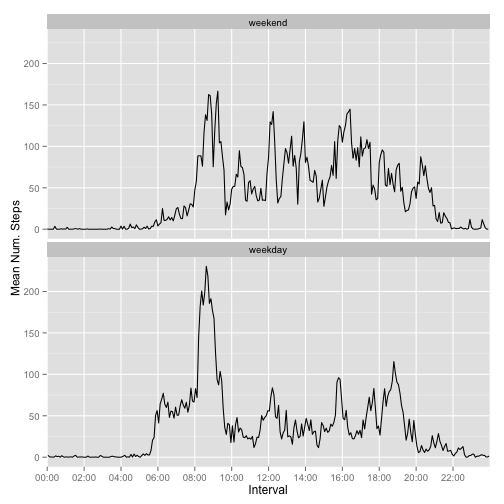

```r
library(ggplot2)
# Create a new factor variable with two levels, "weekday" and "weekend"
actmon_mean_steps_interval <- actmon_imputed
actmon_mean_steps_interval$day <- factor(x=ifelse(weekdays(ymd(actmon_mean_steps_interval$date)) %in%
  c("Saturday","Sunday"),"weekend","weekday"), levels=c("weekend","weekday"))
# Group by both interval and weekday/weekend, get means
actmon_mean_steps_interval <- actmon_mean_steps_interval %>%
  group_by(interval, day) %>%
  summarize(mean_steps=mean(steps))
# Add labels for each interval
actmon_mean_steps_interval$labels <- sub("(\\d\\d)(\\d\\d)", "\\1:\\2",
  formatC(actmon_mean_steps_interval$interval, width=4, format="d", flag="0"))
# Add row numbers, needed for plotting
actmon_mean_steps_interval$rowid <- as.integer(row.names(actmon_mean_steps_interval))
tics <- seq(1, 576, by=48)
# And make the plot
ggplot(actmon_mean_steps_interval, aes(x=rowid, y=mean_steps)) + geom_line() + facet_wrap(~day,ncol=1) +
  xlab("Interval") + ylab("Mean Num. Steps") +
  scale_x_discrete(breaks=tics,labels=actmon_mean_steps_interval[tics,]$labels)
```